# When could you skate in your backyard?

Vincent L. Cannataro, Ph.D. and the IDDS 2201 team

2023-01-18

Around Thanksgiving the winter-loving and backyard-having people of MA build ice rinks in their yard and eagerly await the cold weather. This year, none of those rinks are filled with water yet because the temperatures have not gone below 0C long enough to result in a freeze.

**Is the lack of freezing weather atypical? Getting more common? Cause for concern?**

In *IDDS 2201: Data Analytics* we will learn the tools that allow us to readily analyze these sorts of questions.

# Get weather data

The first thing we need is data. Let’s outline some goals:

- Find historical weather station data
- Download temperature data for analysis

Luckily, the folks at the National Oceanic and Atmospheric Administration publish updated and readily accessible weather data daily: https://data.noaa.gov/onestop/

The data is accessible via https within the directory `https://www.ncei.noaa.gov/pub/data/ghcn/daily/`

And the `readme` file shows that `ghcnd-inventory.txt` contains weather station location and variables measured over time.

```r
# load in the data table containing weather stations
inventory <- read_table(file = "https://www.ncei.noaa.gov/pub/data/ghcn/daily/ghcnd-inventory.txt",
                        col_names = c("station", "lat", "lon", "variable", "start", "end"))

# how big is it?
dim(inventory)
```

```
## [1] 733667      6
```

```r
# That is a lot of rows!
# look at a random 100 rows
inventory %>%
  slice_sample(n = 100) %>%
  DT::datatable()
```

|  | station | lat | lon | variable | start | end |
| --- | --- | --- | --- | --- | --- | --- |
| 1 | MXN00012106 | 17.45 | -98.3833 | TMIN | 1971 | 2012 |
| 2 | USS0014F04S | 43.8 | -114.85 | TOBS | 1978 | 2022 |
| 3 | US1NESB0005 | 41.7166 | -103.6733 | SNWD | 2018 | 2022 |
| 4 | ASN00007124 | -25.2806 | 116.2083 | DAPR | 1972 | 2012 |
| 5 | IN005060900 | 21.88 | 73.5 | PRCP | 1901 | 1969 |
| 6 | USC00061488 | 41.4614 | -72.5197 | WT03 | 1949 | 2000 |
| 7 | USC00305869 | 44.8053 | -74.9997 | WT06 | 1951 | 2001 |
| 8 | USC00225987 | 31.5519 | -90.1058 | WT11 | 1933 | 1992 |
| 9 | USC00419532 | 32.7483 | -97.77 | TOBS | 1917 | 2022 |
| 10 | CA003074880 | 54.55 | -119.5833 | PRCP | 1949 | 2011 |

[output cut: 90 more lines]

We just need to find the weather data closest to coordinates we care about.

## Determine the nearest weather station location

Go to [Google Maps](https://maps.google.com) and right-click anywhere for the lat/long of the location.

```r
# default: suburbia outside Boston
# my_lat <- 42.22135361029577
# my_long <- -71.09712050998877

my_lat <- 42.22135361029577
my_long <- -71.09712050998877
variable_of_interest <- "TMAX"

# for station choice, a number represents the "nth closest station"
# sometimes there is a problem with this station (missing data for decades, etc.),
# so you can also choose the name of the station you want in quotes e.g. "USC00190736"
station_choice <- 1 # "USC00190736"
```

```r
my_station_choices <- inventory %>%
  # distance on a globe "as the crow flies"
  mutate(distance = geosphere::distHaversine(cbind(my_long,my_lat),cbind(lon,lat))) %>%
  # filter out everything except our variable of interest
  filter(variable == variable_of_interest) %>%
  # want recent dates and dates that go back far
  filter(start < 1960 & end > 2020) %>%
  # arrange by ascending distance variable
  arrange(distance)

# display the closest stations
my_station_choices %>%
  slice_head(n = 1000) %>%
  DT::datatable()
```

|  | station | lat | lon | variable | start | end | distance |
| --- | --- | --- | --- | --- | --- | --- | --- |
| 1 | USC00190736 | 42.2122 | -71.1136 | TMAX | 1893 | 2022 | 1698.29440667073 |
| 2 | USW00014739 | 42.3606 | -71.0097 | TMAX | 1936 | 2022 | 17090.9045187118 |
| 3 | USC00190860 | 42.0475 | -71.0081 | TMAX | 1894 | 2022 | 20701.5562419164 |
| 4 | USC00195984 | 41.9928 | -71.1667 | TMAX | 1913 | 2022 | 26083.3279305254 |
| 5 | USW00014702 | 42.4681 | -71.2947 | TMAX | 1949 | 2022 | 31917.6541106042 |
| 6 | USC00194711 | 41.8819 | -70.9086 | TMAX | 1893 | 2022 | 40874.746307145 |
| 7 | USC00194744 | 42.5933 | -71.0186 | TMAX | 1935 | 2022 | 41904.8648422175 |
| 8 | USC00196938 | 41.785 | -70.9175 | TMAX | 1900 | 2022 | 50796.3881271459 |
| 9 | USC00194313 | 42.6408 | -71.3636 | TMAX | 1885 | 2022 | 51571.0781462631 |
| 10 | USC00194105 | 42.6992 | -71.1658 | TMAX | 1893 | 2022 | 53491.8086369882 |

[output cut: 990 more lines]

```r
# if statements to pick either the station you chose (character) or the nth closest station (numeric)

if(is.character(station_choice)){
  my_station <- station_choice
}

if(is.numeric(station_choice)){
  my_station <- my_station_choices$station[station_choice]
}
```

## Download the data

Once our weather station is chosen we can paste it into the URL at noaa.gov and directly read in the data.

```r
station_daily <- paste0("https://www.ncei.noaa.gov/pub/data/ghcn/daily/by_station/",my_station,".csv.gz")

# read in the data, specifying column names and "types" of data
local_weather <- read_csv(station_daily,
                          col_names = c("station", "date", "variable", "value", "a", "b", "c", "d"),
                          col_types = "cdcdcccc")


local_weather %>%
  slice_head(n = 100) %>%
  DT::datatable()
```

|  | station | date | variable | value | a | b | c | d |
| --- | --- | --- | --- | --- | --- | --- | --- | --- |
| 1 | USC00190736 | 18930101 | TMAX | 33 |  |  | 6 | 2000 |
| 2 | USC00190736 | 18930102 | TMAX | 117 |  |  | 6 | 2000 |
| 3 | USC00190736 | 18930103 | TMAX | 0 |  | I | 6 | 2000 |
| 4 | USC00190736 | 18930104 | TMAX | -89 |  |  | 6 | 2000 |
| 5 | USC00190736 | 18930105 | TMAX | -28 |  |  | 6 | 2000 |
| 6 | USC00190736 | 18930106 | TMAX | -83 |  |  | 6 | 2000 |
| 7 | USC00190736 | 18930107 | TMAX | -67 |  |  | 6 | 2000 |
| 8 | USC00190736 | 18930108 | TMAX | -67 |  |  | 6 | 2000 |
| 9 | USC00190736 | 18930109 | TMAX | -28 |  |  | 6 | 2000 |
| 10 | USC00190736 | 18930110 | TMAX | -6 |  |  | 6 | 2000 |

[output cut: 90 more lines]

# Cleaning the data

```r
local_weather <- local_weather %>%
  select(date, variable, value) %>%
  pivot_wider(names_from = "variable", values_from="value",
              values_fill = 0) %>%
  select(date, TMIN,
         # TAVG,
         TMAX,PRCP, SNOW) %>%
  mutate(date = lubridate::ymd(date)) %>%
  # values are in "tenth"s
  mutate(TMIN = TMIN/10,
         # TAVG = TAVG/10,
         TMAX = TMAX/10,
         PRCP = PRCP/10,
         SNOW = SNOW/10)


DT::datatable(local_weather[1:100,]) # much better
```

|  | date | TMIN | TMAX | PRCP | SNOW |
| --- | --- | --- | --- | --- | --- |
| 1 | 1893-01-01 | -5.6 | 3.3 | 0 | 0 |
| 2 | 1893-01-02 | 1.1 | 11.7 | 5.6 | 0 |
| 3 | 1893-01-03 | -10.6 | 0 | 18.5 | 0 |
| 4 | 1893-01-04 | -16.1 | -8.9 | 0 | 0 |
| 5 | 1893-01-05 | -10.6 | -2.8 | 0 | 0 |
| 6 | 1893-01-06 | -13.3 | -8.3 | 0 | 0 |
| 7 | 1893-01-07 | -14.4 | -6.7 | 0 | 0 |
| 8 | 1893-01-08 | -11.7 | -6.7 | 0 | 0 |
| 9 | 1893-01-09 | -16.1 | -2.8 | 0 | 0 |
| 10 | 1893-01-10 | -15.6 | -0.6 | 0 | 0 |

[output cut: 90 more lines]

We need to determine how many days one can have a completed, frozen, ice rink in their backyard.

Below, I calculate this by determining the span of continuous days where the max temp does not pass above 0C, and then subtracting 3 from this max number per span (assuming it takes about 3 days for the water to freeze—information procured from a very knowledgable neighbor!)

```r
local_weather <- local_weather %>%
  mutate(is_frozen = TMAX<=0) %>%
  mutate(year = lubridate::year(date)) %>%
  arrange(date) %>%
  mutate(frozen_span = 0)

if(local_weather$is_frozen[1]){local_weather$frozen_span[1] <- 1}

local_weather$max_frozen_span <- 0

for(row_ind in 2:nrow(local_weather)){

  if(local_weather$is_frozen[row_ind]){
    local_weather$frozen_span[row_ind] <- local_weather$frozen_span[row_ind-1] +1
  }

  if(local_weather$is_frozen[row_ind] == F &
     local_weather$is_frozen[row_ind-1] == T){

    local_weather$max_frozen_span[row_ind] <- local_weather$frozen_span[row_ind-1]

  }

}



frozen_span_df <- local_weather %>%
  filter(max_frozen_span>0) %>%
  select(date, year, max_frozen_span)

days_to_freeze <- 3

local_weather <- local_weather %>%
  mutate(days_frozen = case_when(max_frozen_span > days_to_freeze ~ max_frozen_span - days_to_freeze,
                                 TRUE ~ 0))

# how many total frozen days per year?
frozen_days <- local_weather %>%
  group_by(year) %>%
  summarize(total_freeze = sum(days_frozen))
```

# Visualizing the data

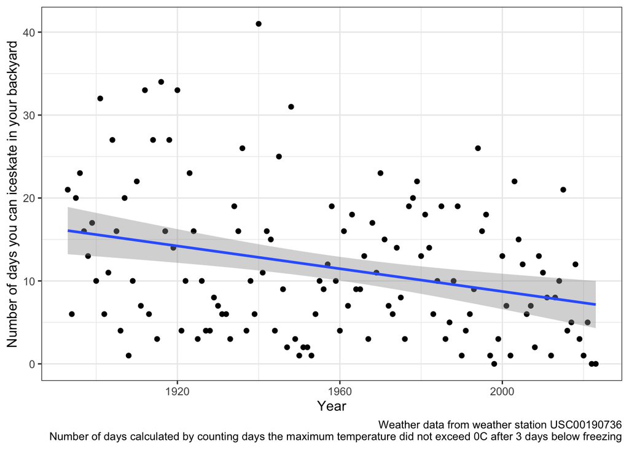

```r
frozen_days %>%
  ggplot(aes(x=year,y=total_freeze)) +
  geom_point() +
  geom_smooth(method = "lm") +
  theme_bw() +
  labs(x="Year", y="Number of days you can iceskate in your backyard",
       caption = paste0("Weather data from weather station ",my_station, "
                        Number of days calculated by counting days the maximum temperature did not exceed 0C after ",days_to_freeze," days below freezing"))
```

In class, we will talk about what we assume when we pick a linear model. Would this model make sense outside of the time span here?

```r
lm(formula = total_freeze ~ year, data = frozen_days) %>% summary()
```

```
##
## Call:
## lm(formula = total_freeze ~ year, data = frozen_days)
##
## Residuals:
##     Min      1Q  Median      3Q     Max
## -14.039  -6.800  -1.776   4.889  28.155
##
## Coefficients:
##              Estimate Std. Error t value Pr(>|t|)
## (Intercept) 145.84756   37.47008   3.892 0.000158 ***
## year         -0.06856    0.01913  -3.583 0.000480 ***
## ---
## Signif. codes:  0 '***' 0.001 '**' 0.01 '*' 0.05 '.' 0.1 ' ' 1
##
## Residual standard error: 8.281 on 129 degrees of freedom
## Multiple R-squared:  0.09052,    Adjusted R-squared:  0.08347
## F-statistic: 12.84 on 1 and 129 DF,  p-value: 0.0004798
```

Here are all the data:

```r
frozen_days %>%
  DT::datatable()
```

|  | year | total_freeze |
| --- | --- | --- |
| 1 | 1893 | 21 |
| 2 | 1894 | 6 |
| 3 | 1895 | 20 |
| 4 | 1896 | 23 |
| 5 | 1897 | 16 |
| 6 | 1898 | 13 |
| 7 | 1899 | 17 |
| 8 | 1900 | 10 |
| 9 | 1901 | 32 |
| 10 | 1902 | 6 |

[output cut: 121 more lines]

# Acknowledgements

Thank you to Prof. Pat Schloss for [inspiration](https://github.com/riffomonas/climate_viz) on downloading weather data.